# LLM Fine-tuning for CNL Classification (Shareable Demo)

This notebook is a lightweight, public demo using fake CNL-style data.

It demonstrates:

- hierarchical classification (domain/component/item)
- baseline vs fine-tuned surrogate model
- validation metrics by depth
- category heterogeneity
- error locality diagnostic
- abstractness vs accuracy heatmap

> Note: This notebook intentionally avoids real/restricted data.

```python
# Full real pipeline (Qwen base model + LoRA fine-tuning) in one contained cell.
# This is the SAME training/eval entrypoint flow used in the project.
#
# How to hook your own base model:
# 1) Set BASE_MODEL_PATH to your local Qwen base-model directory.
# 2) That folder must contain config/tokenizer/model files expected by run_finetune.py.
# 3) Keep OPENAI_API_KEY set when synthetic generation is enabled.
#
# This cell is intentionally OFF by default because it performs real training and evaluation.

from pathlib import Path
import os
import shlex
import shutil
import subprocess
import sys

RUN_REAL_PIPELINE = False          # Set True to execute full training.
RUN_EVAL_AND_HOOK_PLOTS = False    # If True, also runs eval and copies files into plot_stats/.
EPOCHS = 2

REPO_ROOT = Path.cwd().parent  # notebook is under github_minimal_release/
PY = sys.executable
RUN_FINETUNE = REPO_ROOT / "run_finetune.py"
EVAL_BENCH = REPO_ROOT / "eval" / "benchmark.py"
BASE_MODEL_PATH = REPO_ROOT / "model"  # <-- replace with your own local base-model path if needed
PLOT_STATS_DIR = Path.cwd() / "plot_stats"

if not RUN_FINETUNE.exists():
    raise FileNotFoundError(f"Missing training entrypoint: {RUN_FINETUNE}")
if not EVAL_BENCH.exists():
    raise FileNotFoundError(f"Missing eval entrypoint: {EVAL_BENCH}")

if not RUN_REAL_PIPELINE:
    print("RUN_REAL_PIPELINE=False, so no training started.")
    print("Set RUN_REAL_PIPELINE=True in this cell to run full Qwen training.")
    print(f"Expected base model path: {BASE_MODEL_PATH}")
else:
    if not BASE_MODEL_PATH.exists():
        raise FileNotFoundError(f"Base model path not found: {BASE_MODEL_PATH}")

    if not os.getenv("OPENAI_API_KEY"):
        print("Warning: OPENAI_API_KEY not set. Synthetic generation may fail.")

    # Keep canonical output folder names so eval.benchmark auto-detects adapters exactly.
    out_base = REPO_ROOT / "outputs" / "finetune_base"
    out_eq = REPO_ROOT / "outputs" / "finetune_synthetic_equal"
    out_bl = REPO_ROOT / "outputs" / "finetune_synthetic_balance"
    synth_eq = REPO_ROOT / "outputs" / "synthetic_htc_equal"
    synth_bl = REPO_ROOT / "outputs" / "synthetic_htc_balance"

    commands = [
        [
            PY,
            str(RUN_FINETUNE),
            "--model-path", str(BASE_MODEL_PATH),
            "--epochs", str(EPOCHS),
            "--output-dir", str(out_base),
        ],
        [
            PY,
            str(RUN_FINETUNE),
            "--model-path", str(BASE_MODEL_PATH),
            "--epochs", str(EPOCHS),
            "--synthetic", "equal",
            "--synthetic-data-dir", str(synth_eq),
            "--output-dir", str(out_eq),
        ],
        [
            PY,
            str(RUN_FINETUNE),
            "--model-path", str(BASE_MODEL_PATH),
            "--epochs", str(EPOCHS),
            "--synthetic", "balance",
            "--synthetic-data-dir", str(synth_bl),
            "--output-dir", str(out_bl),
        ],
    ]

    for idx, cmd in enumerate(commands, start=1):
        print(f"\n[{idx}/{len(commands)}] Running:\n  " + " ".join(shlex.quote(x) for x in cmd))
        subprocess.run(cmd, cwd=str(REPO_ROOT), check=True)

    print("\nTraining pipeline complete.")
    print(f"Base FT output: {out_base}")
    print(f"Uniform synthetic output: {out_eq}")
    print(f"Balanced synthetic output: {out_bl}")

    if RUN_EVAL_AND_HOOK_PLOTS:
        eval_out = REPO_ROOT / "outputs" / "eval_benchmark"
        eval_cmd = [
            PY,
            str(EVAL_BENCH),
            "--base-model", str(BASE_MODEL_PATH),
            "--outputs-root", str(REPO_ROOT / "outputs"),
            "--out-dir", str(eval_out),
            "--skip-missing-adapter",
        ]
        print("\nRunning benchmark for plot hookup:\n  " + " ".join(shlex.quote(x) for x in eval_cmd))
        subprocess.run(eval_cmd, cwd=str(REPO_ROOT), check=True)

        PLOT_STATS_DIR.mkdir(parents=True, exist_ok=True)
        needed = [
            "summary.json",
            "category_id_key.tsv",
            "predictions_baseline.jsonl",
            "predictions_finetune.jsonl",
            "predictions_finetune_equal.jsonl",
            "predictions_finetune_balance.jsonl",
        ]
        for fname in needed:
            src = eval_out / fname
            dst = PLOT_STATS_DIR / fname
            if src.exists():
                shutil.copy2(src, dst)
        print(f"Plot hookup complete. Updated files in: {PLOT_STATS_DIR}")

    else:
        print("\nTo hook these outputs to the production-plot cells, enable RUN_EVAL_AND_HOOK_PLOTS=True.")
        print(f"Those plot cells read from: {PLOT_STATS_DIR}")
```

```
RUN_REAL_PIPELINE=False, so no training started.
Set RUN_REAL_PIPELINE=True in this cell to run full Qwen training.
Expected base model path: C:\qwen-finetune\model
```

## Notebook flow (recommended)

1. **Real pipeline (top code cell):** keep `RUN_REAL_PIPELINE=False` for a quick pass, or set it to `True` for full Qwen fine-tuning.
2. If you want fresh production plots from your new run, set `RUN_EVAL_AND_HOOK_PLOTS=True` in that same top cell.
3. Run the demo/diagnostic cells (sample-data surrogate section) for a fast sanity check.
4. Run `Reproduce production plots in-notebook` to regenerate poster/presentation figures from `plot_stats/` into `plots/`.
5. Review the final production figures displayed at the end of the notebook.

```python
import re
from collections import defaultdict

import numpy as np
import pandas as pd
import matplotlib as mpl
import matplotlib.pyplot as plt

from sklearn.dummy import DummyClassifier
from sklearn.feature_extraction.text import TfidfVectorizer
from sklearn.linear_model import LogisticRegression
from sklearn.metrics import accuracy_score, precision_recall_fscore_support
from sklearn.model_selection import train_test_split
from sklearn.pipeline import Pipeline

# Match poster/presentation plotting style
mpl.rcParams.update({
    "figure.dpi": 150,
    "savefig.dpi": 300,
    "font.family": "serif",
    "font.serif": ["Times New Roman", "Times", "DejaVu Serif", "Liberation Serif"],
    "font.size": 8,
    "axes.labelsize": 8,
    "xtick.labelsize": 8,
    "ytick.labelsize": 8,
    "legend.fontsize": 7,
    "axes.linewidth": 0.7,
    "xtick.major.width": 0.7,
    "ytick.major.width": 0.7,
    "xtick.major.size": 3.5,
    "ytick.major.size": 3.5,
    "axes.grid": False,
})

PALETTE = {
    "baseline": "#2B6CB0",
    "finetuned": "#2F855A",
    "uniform": "#B7791F",
    "balanced": "#6B46C1",
}
```

```python
df = pd.read_csv("data/fake_cnl_sample.csv")

item_to_hierarchy = {
    "microsystem structuring": ("Structuring", "Microsystem", "microsystem structuring"),
    "consensus CNL can close gaps": ("Readiness", "Consensus", "consensus CNL can close gaps"),
    "workflow structuring": ("Structuring", "Workflow", "workflow structuring"),
    "support staff engagement": ("Practice", "Staff engagement", "support staff engagement"),
    "facilitate communication": ("Practice", "Communication", "facilitate communication"),
    "improved care environments": ("Outcome", "Care environment", "improved care environments"),
}

hier = df["gold_item"].map(item_to_hierarchy)
df["gold_domain"] = [h[0] for h in hier]
df["gold_component"] = [h[1] for h in hier]

df.head()
```

|  | id | excerpt | gold_item | gold_domain | gold_component |
| --- | --- | --- | --- | --- | --- |
| 0 | 1 | We mapped staffing handoffs and clarified role... | microsystem structuring | Structuring | Microsystem |
| 1 | 2 | Our team redesigned unit workflows so everyone... | microsystem structuring | Structuring | Microsystem |
| 2 | 3 | The CNL helped standardize rounds and role bou... | microsystem structuring | Structuring | Microsystem |
| 3 | 4 | We created one workflow board so nursing and t... | microsystem structuring | Structuring | Microsystem |
| 4 | 5 | The unit now has a clear structure for escalat... | microsystem structuring | Structuring | Microsystem |

```python
train_df, test_df = train_test_split(
    df,
    test_size=0.35,
    random_state=42,
    stratify=df["gold_item"],
)

X_train = train_df["excerpt"].tolist()
X_test = test_df["excerpt"].tolist()
y_train = train_df["gold_item"].tolist()
y_test = test_df["gold_item"].tolist()

baseline = DummyClassifier(strategy="most_frequent")
baseline.fit(X_train, y_train)
y_pred_base = baseline.predict(X_test)

ft_model = Pipeline([
    ("tfidf", TfidfVectorizer(ngram_range=(1, 2), min_df=1)),
    ("clf", LogisticRegression(max_iter=1000, random_state=42)),
])
ft_model.fit(X_train, y_train)
y_pred_ft = ft_model.predict(X_test)

print(f"Train size: {len(train_df)} | Test size: {len(test_df)}")
```

```
Train size: 23 | Test size: 13
```

```python
def to_depth_labels(items, depth):
    out = []
    for it in items:
        dom, comp, item = item_to_hierarchy[it]
        if depth == 1:
            out.append(dom)
        elif depth == 2:
            out.append(comp)
        else:
            out.append(item)
    return out


def metrics_by_depth(y_true_item, y_pred_item):
    rows = []
    for depth, depth_name in [(1, "Domain"), (2, "Component"), (3, "Item")]:
        y_true = to_depth_labels(y_true_item, depth)
        y_pred = to_depth_labels(y_pred_item, depth)

        acc = accuracy_score(y_true, y_pred)
        p, r, f1, _ = precision_recall_fscore_support(y_true, y_pred, average="macro", zero_division=0)
        rows.append({
            "Depth": depth_name,
            "Accuracy": acc,
            "Precision": p,
            "Recall": r,
            "F1": f1,
        })
    return pd.DataFrame(rows)

m_base = metrics_by_depth(y_test, y_pred_base)
m_ft = metrics_by_depth(y_test, y_pred_ft)

m_base["Model"] = "Baseline"
m_ft["Model"] = "Fine-tuned surrogate"
metrics_df = pd.concat([m_base, m_ft], ignore_index=True)
metrics_df
```

|  | Depth | Accuracy | Precision | Recall | F1 | Model |
| --- | --- | --- | --- | --- | --- | --- |
| 0 | Domain | 0.153846 | 0.038462 | 0.250000 | 0.066667 | Baseline |
| 1 | Component | 0.153846 | 0.025641 | 0.166667 | 0.044444 | Baseline |
| 2 | Item | 0.153846 | 0.025641 | 0.166667 | 0.044444 | Baseline |
| 3 | Domain | 0.384615 | 0.333333 | 0.362500 | 0.337500 | Fine-tuned surrogate |
| 4 | Component | 0.384615 | 0.305556 | 0.416667 | 0.350000 | Fine-tuned surrogate |
| 5 | Item | 0.384615 | 0.305556 | 0.416667 | 0.350000 | Fine-tuned surrogate |

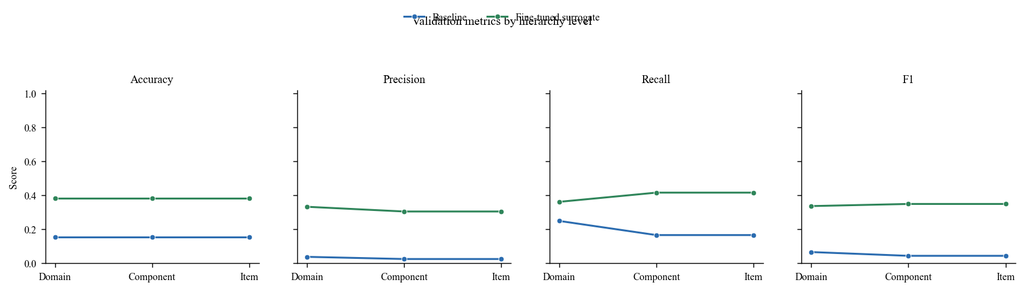

```python
# Validation metrics plot
fig, axes = plt.subplots(1, 4, figsize=(11.4, 3.4), sharex=True, sharey=True)
metrics = ["Accuracy", "Precision", "Recall", "F1"]
colors = {"Baseline": PALETTE["baseline"], "Fine-tuned surrogate": PALETTE["finetuned"]}

depths = ["Domain", "Component", "Item"]
x = np.arange(len(depths))

for ax, m in zip(axes, metrics):
    for model in ["Baseline", "Fine-tuned surrogate"]:
        y = metrics_df.loc[metrics_df["Model"] == model, m].to_numpy()
        ax.plot(
            x,
            y,
            marker="o",
            linewidth=1.5,
            markersize=4.2,
            markeredgecolor="white",
            markeredgewidth=0.45,
            color=colors[model],
            label=model,
        )
    ax.set_title(m, fontsize=9)
    ax.set_xticks(x)
    ax.set_xticklabels(depths, fontsize=8)
    ax.set_ylim(0, 1.02)
    ax.grid(False)
    ax.spines["top"].set_visible(False)
    ax.spines["right"].set_visible(False)

axes[0].set_ylabel("Score")
fig.suptitle("Validation metrics by hierarchy level", y=0.98)
handles, labels = axes[-1].get_legend_handles_labels()
fig.legend(handles, labels, loc="upper center", bbox_to_anchor=(0.5, 1.02), ncol=2, frameon=False, fontsize=8)
fig.subplots_adjust(left=0.06, right=0.995, top=0.74, bottom=0.18, wspace=0.18)
plt.show()
```

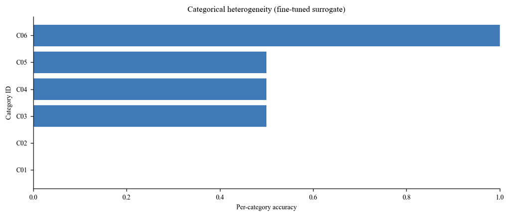

```
Category ID mapping:
```

|  | C | gold_item |
| --- | --- | --- |
| 0 | C01 | microsystem structuring |
| 1 | C02 | improved care environments |
| 2 | C03 | facilitate communication |
| 3 | C04 | consensus CNL can close gaps |
| 4 | C05 | workflow structuring |
| 5 | C06 | support staff engagement |

```python
# Build test-level frame for diagnostics
res = test_df[["excerpt", "gold_item", "gold_domain", "gold_component"]].copy()
res["pred_item_base"] = y_pred_base
res["pred_item_ft"] = y_pred_ft

res["pred_domain_ft"] = [item_to_hierarchy[x][0] for x in res["pred_item_ft"]]
res["pred_component_ft"] = [item_to_hierarchy[x][1] for x in res["pred_item_ft"]]
res["correct_ft"] = (res["pred_item_ft"] == res["gold_item"]).astype(int)

# Category heterogeneity (fine-tuned surrogate)
cat_acc = res.groupby("gold_item", as_index=False)["correct_ft"].mean().sort_values("correct_ft")
cat_acc = cat_acc.reset_index(drop=True)
cat_acc["C"] = [f"C{i+1:02d}" for i in range(len(cat_acc))]

fig_h = max(3.6, 0.34 * len(cat_acc))
fig, ax = plt.subplots(figsize=(8.4, fig_h))
ax.barh(cat_acc["C"], cat_acc["correct_ft"], color="#2B6CB0", alpha=0.9)
ax.set_xlim(0, 1)
ax.set_xlabel("Per-category accuracy")
ax.set_ylabel("Category ID")
ax.set_title("Categorical heterogeneity (fine-tuned surrogate)")
ax.grid(False)
ax.spines["top"].set_visible(False)
ax.spines["right"].set_visible(False)
ax.tick_params(axis="y", labelsize=8)
fig.tight_layout()
plt.show()

print("Category ID mapping:")
display(cat_acc[["C", "gold_item"]])
```

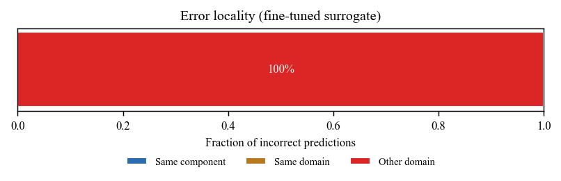

```python
# Error locality: among WRONG predictions, where did it land?
wrong = res[res["correct_ft"] == 0].copy()

same_component = (wrong["pred_component_ft"] == wrong["gold_component"]).sum()
same_domain = ((wrong["pred_component_ft"] != wrong["gold_component"]) & (wrong["pred_domain_ft"] == wrong["gold_domain"])).sum()
other_domain = (wrong["pred_domain_ft"] != wrong["gold_domain"]).sum()

tot_wrong = max(len(wrong), 1)
vals = np.array([same_component, same_domain, other_domain], dtype=float) / tot_wrong
labels = ["Same component", "Same domain", "Other domain"]
colors = ["#2B6CB0", "#B7791F", "#DC2626"]

plt.figure(figsize=(6.5, 1.8))
left = 0.0
for v, lab, c in zip(vals, labels, colors):
    plt.barh([0], [v], left=left, color=c, edgecolor="white", label=lab)
    if v > 0.08:
        plt.text(left + v/2, 0, f"{100*v:.0f}%", ha="center", va="center", color="white", fontsize=8)
    left += v

plt.xlim(0, 1)
plt.yticks([])
plt.xlabel("Fraction of incorrect predictions")
plt.title("Error locality (fine-tuned surrogate)")
plt.legend(frameon=False, loc="upper center", bbox_to_anchor=(0.5, -0.45), ncol=3)
plt.gcf().subplots_adjust(bottom=0.44)
plt.show()
```

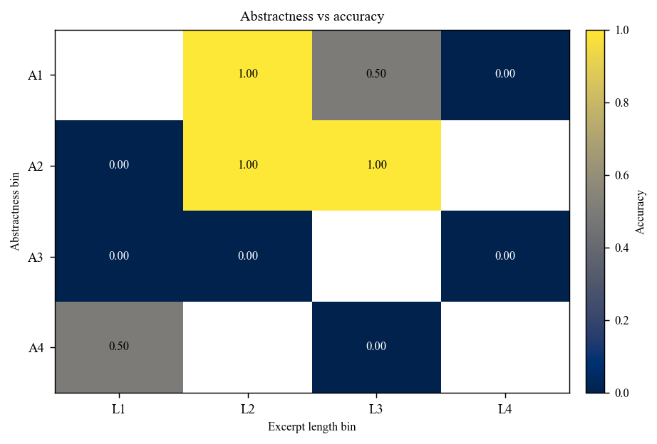

```python
# Abstractness vs accuracy heatmap (simple heuristic)
def tokenize(text):
    return re.findall(r"[A-Za-z']+", text.lower())

# lexical commonness estimated from training corpus
freq = defaultdict(int)
for t in train_df["excerpt"]:
    for w in tokenize(t):
        freq[w] += 1
maxf = max(freq.values())

suffixes = ("tion", "sion", "ment", "ness", "ity")

def abstractness_score(text):
    toks = tokenize(text)
    if not toks:
        return 0.0
    nom_rate = sum(1 for w in toks if w.endswith(suffixes)) / len(toks)
    commonness = np.mean([np.log1p(freq.get(w, 0)) / np.log1p(maxf) for w in toks])
    # higher score = more abstract (more nominalization, less common wording)
    return 0.5 * nom_rate + 0.5 * (1.0 - commonness)

res["len_tokens"] = res["excerpt"].map(lambda x: len(tokenize(x)))
res["abstractness"] = res["excerpt"].map(abstractness_score)

res["len_bin"] = pd.qcut(res["len_tokens"], q=4, labels=["L1", "L2", "L3", "L4"])
res["abs_bin"] = pd.qcut(res["abstractness"], q=4, labels=["A1", "A2", "A3", "A4"])

pivot = res.pivot_table(index="abs_bin", columns="len_bin", values="correct_ft", aggfunc="mean")

fig, ax = plt.subplots(figsize=(6.2, 4.2))
im = ax.imshow(pivot.values, vmin=0, vmax=1, cmap="cividis", aspect="auto")
ax.set_xticks(range(len(pivot.columns)))
ax.set_xticklabels(pivot.columns, fontsize=9)
ax.set_yticks(range(len(pivot.index)))
ax.set_yticklabels(pivot.index, fontsize=9)
ax.set_xlabel("Excerpt length bin")
ax.set_ylabel("Abstractness bin")
ax.set_title("Abstractness vs accuracy")
for i in range(pivot.shape[0]):
    for j in range(pivot.shape[1]):
        v = pivot.values[i, j]
        if np.isfinite(v):
            ax.text(j, i, f"{v:.2f}", ha="center", va="center", color="white" if v < 0.5 else "black", fontsize=8)
cbar = fig.colorbar(im, ax=ax, fraction=0.045, pad=0.03)
cbar.set_label("Accuracy")
fig.tight_layout()
plt.show()
```

```python
# Example predictions: one correct and one error
res["pred_ok"] = np.where(res["correct_ft"] == 1, "Correct", "Error")
show_cols = ["excerpt", "gold_item", "pred_item_ft", "pred_ok"]

print("Example correct prediction:")
display(res[res["correct_ft"] == 1][show_cols].head(1))

print("Example error prediction:")
display(res[res["correct_ft"] == 0][show_cols].head(1))
```

```
Example correct prediction:
```

|  | excerpt | gold_item | pred_item_ft | pred_ok |
| --- | --- | --- | --- | --- |
| 19 | Nurses began leading improvement ideas because... | support staff engagement | support staff engagement | Correct |

```
Example error prediction:
```

|  | excerpt | gold_item | pred_item_ft | pred_ok |
| --- | --- | --- | --- | --- |
| 1 | Our team redesigned unit workflows so everyone... | microsystem structuring | facilitate communication | Error |

## Summary

- The fine-tuned surrogate improves hierarchical metrics over baseline.
- Performance is heterogeneous across categories.
- Error locality and abstractness diagnostics provide interpretable failure analysis.

This shareable notebook mirrors the project workflow while using only safe, fake data.

## Production Figures (Poster/Presentation)

These are the final poster/presentation figures generated by the reproduction cells later in this notebook. They are written to `plots/` and displayed at the end.

- `plots/fig_accuracy_hierarchy.png`
- `plots/fig_validation_metrics_all_models.png`
- `plots/fig_category_accuracy_compact_compare.png`
- `plots/fig_assumption_error_locality_models.png`
- `plots/fig_diagnostic_error_vs_support_models.png`
- `plots/fig_assumption_length_abstractness_heatmap4.png`

Exact script sources remain available under `scripts/` for traceability.

```python
# Static duplicate display removed intentionally.
# Regenerated figures are shown after the in-notebook reproduction cell below.
```

## Metric definitions used in validation

At each hierarchy depth (Domain, Component, Item):

- Accuracy = proportion of correct labels.
- Precision (macro) = average of classwise precision across labels.
- Recall (macro) = average of classwise recall across labels.
- F1 (macro) = average of classwise F1 across labels.

Where for class `k`:  
`Precision_k = TP_k / (TP_k + FP_k)`  
`Recall_k = TP_k / (TP_k + FN_k)`  
`F1_k = 2 * Precision_k * Recall_k / (Precision_k + Recall_k)`

Macro averaging gives each class equal weight.

## Reproduce production plots in-notebook

This section contains the plotting code directly in notebook cells.

Input files expected in `plot_stats/`:

- `summary.json`
- `category_id_key.tsv`
- `predictions_baseline.jsonl`
- `predictions_finetune.jsonl`
- `predictions_finetune_equal.jsonl`
- `predictions_finetune_balance.jsonl`

If you run the top training cell with `RUN_EVAL_AND_HOOK_PLOTS=True`, these inputs are refreshed automatically and then this section regenerates figures into `plots/`.

```python
from pathlib import Path
import json
from collections import defaultdict

import numpy as np
import matplotlib as mpl
import matplotlib.pyplot as plt
from sklearn.metrics import accuracy_score, precision_recall_fscore_support
from wordfreq import zipf_frequency
import re

DATA_DIR = Path("plot_stats")
OUT_DIR = Path("plots")
OUT_DIR.mkdir(parents=True, exist_ok=True)

print("Inputs:", DATA_DIR.resolve())
print("Outputs:", OUT_DIR.resolve())
```

```
Inputs: C:\qwen-finetune\github_minimal_release\plot_stats
Outputs: C:\qwen-finetune\github_minimal_release\plots
```

```python
# Exact plotting logic embedded in notebook (adapted directly from project scripts)

VARIANTS = [
    ("baseline", "Baseline", "#2B6CB0"),
    ("finetune", "Fine-tuned (original)", "#2F855A"),
    ("finetune_equal", "Fine-tuned + synthetic (uniform)", "#B7791F"),
    ("finetune_balance", "Fine-tuned + synthetic (class-balanced)", "#6B46C1"),
]

def _rc():
    mpl.rcParams.update({
        "figure.dpi": 150,
        "savefig.dpi": 300,
        "font.family": "serif",
        "font.serif": ["Times New Roman", "Times", "DejaVu Serif", "Liberation Serif"],
        "font.size": 8,
        "axes.labelsize": 8,
        "xtick.labelsize": 8,
        "ytick.labelsize": 8,
        "legend.fontsize": 7,
        "axes.linewidth": 0.7,
        "xtick.major.width": 0.7,
        "ytick.major.width": 0.7,
        "axes.grid": False,
    })

def load_json(path):
    return json.loads(Path(path).read_text(encoding="utf-8"))

def load_jsonl(path):
    rows = []
    for ln in Path(path).read_text(encoding="utf-8").splitlines():
        ln = ln.strip()
        if ln:
            rows.append(json.loads(ln))
    return rows

def wilson(p, n, z=1.96):
    if n <= 0:
        return p, p
    denom = 1.0 + (z * z) / n
    center = (p + (z * z) / (2.0 * n)) / denom
    spread = (z / denom) * float(np.sqrt((p * (1.0 - p) / n) + ((z * z) / (4.0 * n * n))))
    return max(0.0, center - spread), min(1.0, center + spread)

def split_path(s):
    return tuple(x.strip() for x in str(s).split(">") if x.strip())

# 1) Accuracy by hierarchy depth
_rc()
summary = load_json(DATA_DIR / "summary.json")
depths = (1, 2, 3)
labels = []
vals = []
for v in [x for x in summary.get("variants", []) if not x.get("skipped")]:
    key = str(v.get("key", ""))
    lbl = {
        "baseline": "Baseline",
        "finetune": "Fine-tuned (original)",
        "finetune_equal": "Fine-tuned + synthetic (uniform)",
        "finetune_balance": "Fine-tuned + synthetic (class-balanced)",
    }.get(key, key)
    by_d = (v.get("metrics") or {}).get("hierarchy_acc_by_depth") or {}
    labels.append(lbl)
    vals.append([float(by_d.get(str(d), 0.0)) for d in depths])

pred_base = load_jsonl(DATA_DIR / "predictions_baseline.jsonl")
n_by_depth = {d: sum(1 for r in pred_base if len(split_path(r.get("gold", ""))) >= d) for d in depths}

arr = np.array(vals, dtype=float)
x = np.arange(len(depths), dtype=float)
fig, ax = plt.subplots(figsize=(89 / 25.4, (89 / 25.4) * 0.64), layout="constrained")
markers = ["o", "s", "D", "^"]
for i in range(arr.shape[0]):
    y = arr[i]
    lo, hi = [], []
    for j, d in enumerate(depths):
        a, b = wilson(float(y[j]), int(n_by_depth[d]))
        lo.append(float(y[j] - a))
        hi.append(float(b - y[j]))
    ax.plot(x, y, color=VARIANTS[i][2], linewidth=1.15, marker=markers[i], markersize=4.2, markeredgecolor="white", markeredgewidth=0.5, label=labels[i], zorder=4)
    ax.errorbar(x, y, yerr=np.array([lo, hi]), fmt="none", ecolor=VARIANTS[i][2], elinewidth=0.8, capsize=2.0, capthick=0.8, zorder=3)
ax.set_xticks(x)
ax.set_xticklabels([str(d) for d in depths])
ax.set_xlabel("Hierarchy depth")
ax.set_ylabel("Accuracy")
ax.set_ylim(0, 0.72)
ax.set_yticks(np.arange(0.0, 0.71, 0.1))
ax.legend(frameon=False, loc="upper center", bbox_to_anchor=(0.5, 1.01), ncol=2, borderaxespad=0, handlelength=1.2, handletextpad=0.4, labelspacing=0.15, columnspacing=0.7, fontsize=6)
ax.spines["top"].set_visible(False)
ax.spines["right"].set_visible(False)
ax.grid(False)
fig.savefig(OUT_DIR / "fig_accuracy_hierarchy.png", bbox_inches="tight", pad_inches=0.02)
fig.savefig(OUT_DIR / "fig_accuracy_hierarchy.pdf", bbox_inches="tight", pad_inches=0.02)
plt.close(fig)

# 2) Category accuracy compact compare
_rc()
key_rows = []
for ln in (DATA_DIR / "category_id_key.tsv").read_text(encoding="utf-8").splitlines()[1:]:
    if ln.strip():
        cid, cat, n = ln.split("\t")
        key_rows.append({"C": cid, "category": cat, "n": int(n)})

def aggregate(rows):
    d = defaultdict(lambda: {"n": 0, "correct": 0})
    for r in rows:
        g = str(r.get("gold", "")).strip()
        if not g:
            continue
        d[g]["n"] += 1
        d[g]["correct"] += int(bool(r.get("exact_match")))
    return {k: (v["correct"] / v["n"] if v["n"] else 0.0) for k, v in d.items()}

acc_by = {
    "baseline": aggregate(load_jsonl(DATA_DIR / "predictions_baseline.jsonl")),
    "finetune": aggregate(load_jsonl(DATA_DIR / "predictions_finetune.jsonl")),
    "finetune_equal": aggregate(load_jsonl(DATA_DIR / "predictions_finetune_equal.jsonl")),
    "finetune_balance": aggregate(load_jsonl(DATA_DIR / "predictions_finetune_balance.jsonl")),
}
mat = np.zeros((len(key_rows), len(VARIANTS)), dtype=float)
for i, r in enumerate(key_rows):
    for j, (k, _, _) in enumerate(VARIANTS):
        mat[i, j] = float(acc_by.get(k, {}).get(r["category"], 0.0))

fig, ax = plt.subplots(figsize=(320 / 25.4, 5.3))
xx = np.arange(len(key_rows), dtype=float)
group_w = 0.80
bar_w = group_w / len(VARIANTS)
offsets = np.linspace(-(group_w - bar_w) / 2.0, (group_w - bar_w) / 2.0, len(VARIANTS))
for j, (_, lbl, color) in enumerate(VARIANTS):
    ax.bar(xx + offsets[j], mat[:, j], width=bar_w * 0.92, color=color, edgecolor="white", linewidth=0.45, alpha=0.95, label=lbl, zorder=3)
ax.set_ylim(0, 1.0)
ax.set_yticks(np.arange(0, 1.01, 0.1))
ax.set_ylabel("Category accuracy", fontsize=11)
ax.set_xticks(xx)
ax.set_xticklabels([f"{r['C']} (n={r['n']})" for r in key_rows], rotation=32, ha="right")
ax.set_xlabel("Category", fontsize=11)
ax.tick_params(axis="x", labelsize=7.5)
ax.tick_params(axis="y", labelsize=10)
ax.legend(frameon=False, loc="upper center", bbox_to_anchor=(0.5, 1.02), ncol=4, fontsize=9, handlelength=1.1, handletextpad=0.4, labelspacing=0.2, columnspacing=0.8)
ax.spines["top"].set_visible(False)
ax.spines["right"].set_visible(False)
ax.grid(False)
fig.subplots_adjust(left=0.06, right=0.995, top=0.90, bottom=0.34)
fig.savefig(OUT_DIR / "fig_category_accuracy_compact_compare.png", bbox_inches="tight", pad_inches=0.02)
fig.savefig(OUT_DIR / "fig_category_accuracy_compact_compare.pdf", bbox_inches="tight", pad_inches=0.02)
plt.close(fig)
```

```python
# 3) Validation metrics all models
_rc()
def label_at_depth(path, depth):
    p = split_path(path)
    return p[depth - 1] if len(p) >= depth else ""

def metrics_for_depth(rows, depth):
    gold, pred = [], []
    for r in rows:
        g = label_at_depth(r.get("gold", ""), depth)
        p = label_at_depth(r.get("pred_matched", ""), depth)
        if not g:
            continue
        gold.append(g)
        pred.append(p)
    if not gold:
        return {"accuracy": 0.0, "precision": 0.0, "recall": 0.0, "f1": 0.0}
    acc = float(accuracy_score(gold, pred))
    pr, rc, f1, _ = precision_recall_fscore_support(gold, pred, average="macro", zero_division=0)
    return {"accuracy": acc, "precision": float(pr), "recall": float(rc), "f1": float(f1)}

rows_by = {
    "baseline": load_jsonl(DATA_DIR / "predictions_baseline.jsonl"),
    "finetune": load_jsonl(DATA_DIR / "predictions_finetune.jsonl"),
    "finetune_equal": load_jsonl(DATA_DIR / "predictions_finetune_equal.jsonl"),
    "finetune_balance": load_jsonl(DATA_DIR / "predictions_finetune_balance.jsonl"),
}
DEPTHS = [(1, "Domain"), (2, "Component"), (3, "Item")]
METRICS = ("accuracy", "precision", "recall", "f1")
res = {k: {dn: metrics_for_depth(rows, d) for d, dn in DEPTHS} for k, rows in rows_by.items()}

fig, axes = plt.subplots(1, 4, figsize=(250 / 25.4, 72 / 25.4), sharex=True, sharey=True)
xd = np.arange(len(DEPTHS), dtype=float)
depth_names = [d for _, d in DEPTHS]
markers = ["o", "s", "D", "^"]
for ax, m in zip(axes, METRICS):
    for i, (k, lbl, color) in enumerate(VARIANTS):
        y = np.array([float(res[k][dn][m]) for dn in depth_names], dtype=float)
        ax.plot(xd, y, color=color, marker=markers[i], markersize=4.2, linewidth=1.3, markeredgecolor="white", markeredgewidth=0.45, label=lbl, zorder=3)
    ax.set_title(m.capitalize(), fontsize=8.5)
    ax.set_xticks(xd)
    ax.set_xticklabels(depth_names)
    ax.set_ylim(0.0, 1.02)
    ax.set_yticks(np.arange(0, 1.01, 0.1))
    ax.spines["top"].set_visible(False)
    ax.spines["right"].set_visible(False)
    ax.grid(False)
axes[0].set_ylabel("Score")
fig.supxlabel("Hierarchy level")
h, l = axes[-1].get_legend_handles_labels()
fig.legend(h, l, frameon=False, loc="upper center", bbox_to_anchor=(0.5, 1.02), ncol=2, handletextpad=0.35, columnspacing=0.8, labelspacing=0.2)
fig.subplots_adjust(left=0.06, right=0.995, top=0.78, bottom=0.19, wspace=0.18)
fig.savefig(OUT_DIR / "fig_validation_metrics_all_models.png", bbox_inches="tight", pad_inches=0.02)
fig.savefig(OUT_DIR / "fig_validation_metrics_all_models.pdf", bbox_inches="tight", pad_inches=0.02)
plt.close(fig)

# 4) Error locality + error vs support
_rc()
def norm_label(s):
    return " ".join(str(s).strip().lower().split())

def shared_prefix_depth(pred, gold):
    pp = [norm_label(x) for x in str(pred).split(">") if x.strip()]
    gg = [norm_label(x) for x in str(gold).split(">") if x.strip()]
    d = 0
    for a, b in zip(pp, gg):
        if a != b:
            break
        d += 1
    return d

def locality_breakdown(rows):
    wrong = 0
    c = {"same_component": 0, "same_domain": 0, "other_domain": 0}
    for r in rows:
        g = str(r.get("gold", "")).strip()
        p = str(r.get("pred_matched", "")).strip()
        if not g or p == g:
            continue
        wrong += 1
        d = shared_prefix_depth(p, g) if p else 0
        if d >= 2:
            c["same_component"] += 1
        elif d == 1:
            c["same_domain"] += 1
        else:
            c["other_domain"] += 1
    return {k: (c[k] / wrong if wrong else 0.0) for k in c}

sel = ["finetune", "finetune_equal", "finetune_balance"]
local = {k: locality_breakdown(rows_by[k]) for k in sel}
fig, ax = plt.subplots(figsize=(170 / 25.4, 62 / 25.4))
y = np.arange(len(sel), dtype=float)
left = np.zeros(len(sel), dtype=float)
parts = [("same_component", "Wrong: same component", "#2B6CB0"), ("same_domain", "Wrong: same domain", "#B7791F"), ("other_domain", "Wrong: other domain", "#DC2626")]
for key, lab, col in parts:
    v = np.array([local[k][key] for k in sel], dtype=float)
    ax.barh(y, v, left=left, height=0.62, color=col, edgecolor="white", linewidth=0.5, label=lab, zorder=2)
    for i, vv in enumerate(v):
        if vv >= 0.07:
            ax.text(left[i] + vv / 2.0, y[i], f"{100*vv:.0f}%", va="center", ha="center", color="white", fontsize=7)
    left += v
ax.set_xlim(0, 1.0)
ax.set_xticks(np.arange(0, 1.01, 0.1))
ax.set_xlabel("Fraction of incorrect predictions")
ax.set_yticks(y)
ax.set_yticklabels([dict((k, v) for k, v, _ in VARIANTS)[k] for k in sel])
ax.set_title("When wrong, where does the misclassification land?", fontsize=8.8)
ax.invert_yaxis()
ax.spines["top"].set_visible(False)
ax.spines["right"].set_visible(False)
ax.grid(False)
ax.legend(frameon=False, loc="upper center", bbox_to_anchor=(0.5, -0.34), ncol=3, columnspacing=0.85, handletextpad=0.35)
fig.subplots_adjust(bottom=0.36)
fig.savefig(OUT_DIR / "fig_assumption_error_locality_models.png", bbox_inches="tight", pad_inches=0.02)
fig.savefig(OUT_DIR / "fig_assumption_error_locality_models.pdf", bbox_inches="tight", pad_inches=0.02)
plt.close(fig)

cid_by_cat = {r["category"]: r["C"] for r in key_rows}
def per_class_error(rows):
    n_by = defaultdict(int)
    e_by = defaultdict(int)
    for r in rows:
        g = str(r.get("gold", "")).strip()
        if not g:
            continue
        n_by[g] += 1
        e_by[g] += 0 if bool(r.get("exact_match")) else 1
    cats = [c for c in n_by]
    return cats, np.array([float(e_by[c] / n_by[c]) for c in cats], dtype=float), np.array([float(n_by[c]) for c in cats], dtype=float)

cats, err_ft, sup = per_class_error(rows_by["finetune"])
err_eq_map = {c: e for c, e in zip(*per_class_error(rows_by["finetune_equal"])[0:2])}
err_bl_map = {c: e for c, e in zip(*per_class_error(rows_by["finetune_balance"])[0:2])}
err_eq = np.array([float(err_eq_map.get(c, 0.0)) for c in cats], dtype=float)
err_bl = np.array([float(err_bl_map.get(c, 0.0)) for c in cats], dtype=float)
log_sup = np.log10(np.maximum(sup, 1.0))
xf = np.linspace(float(np.min(log_sup)), float(np.max(log_sup)), 120)
```

```python
def spearman_rho(xv, yv):
    rx = np.argsort(np.argsort(xv)).astype(float)
    ry = np.argsort(np.argsort(yv)).astype(float)
    rx = (rx - rx.mean()) / (rx.std() + 1e-12)
    ry = (ry - ry.mean()) / (ry.std() + 1e-12)
    return float(np.mean(rx * ry))

fig, axes = plt.subplots(1, 2, figsize=(240 / 25.4, 82 / 25.4), sharex=True)
jitter = {"finetune": -0.006, "finetune_equal": 0.0, "finetune_balance": 0.006}
series = [("finetune", err_ft), ("finetune_equal", err_eq), ("finetune_balance", err_bl)]
for k, yv in series:
    sl, ic = np.polyfit(log_sup, yv, deg=1)
    axes[0].scatter(log_sup + jitter[k], yv, s=26, alpha=0.88, color=dict((kk, cc) for kk, _, cc in VARIANTS)[k], edgecolor="white", linewidth=0.45, label=dict((kk, ll) for kk, ll, _ in VARIANTS)[k], zorder=3)
    axes[0].plot(xf, sl * xf + ic, color=dict((kk, cc) for kk, _, cc in VARIANTS)[k], linewidth=1.2, alpha=0.92, zorder=2)
axes[0].set_xlabel("log10(class support n)")
axes[0].set_ylabel("Class error rate")
axes[0].set_ylim(-0.02, 1.02)
axes[0].set_title("Per-class error vs support", fontsize=8.5)
axes[0].spines["top"].set_visible(False)
axes[0].spines["right"].set_visible(False)
axes[0].grid(False)
axes[0].legend(frameon=False, loc="lower right", handletextpad=0.35, labelspacing=0.22)

delta_eq = err_ft - err_eq
delta_bl = err_ft - err_bl
sl_e, ic_e = np.polyfit(log_sup, delta_eq, deg=1)
sl_b, ic_b = np.polyfit(log_sup, delta_bl, deg=1)
axes[1].scatter(log_sup, delta_eq, s=26, alpha=0.9, color=dict((kk, cc) for kk, _, cc in VARIANTS)["finetune_equal"], edgecolor="white", linewidth=0.45, label="FT+Synthetic (uniform) - FT", zorder=3)
axes[1].plot(xf, sl_e * xf + ic_e, color=dict((kk, cc) for kk, _, cc in VARIANTS)["finetune_equal"], linewidth=1.2, zorder=2)
axes[1].scatter(log_sup + 0.006, delta_bl, s=26, alpha=0.9, color=dict((kk, cc) for kk, _, cc in VARIANTS)["finetune_balance"], edgecolor="white", linewidth=0.45, label="FT+Synthetic (balanced) - FT", zorder=3)
axes[1].plot(xf, sl_b * xf + ic_b, color=dict((kk, cc) for kk, _, cc in VARIANTS)["finetune_balance"], linewidth=1.2, zorder=2)
axes[1].axhline(0.0, color="#9CA3AF", linestyle="--", linewidth=1.0, zorder=1)
axes[1].set_xlabel("log10(class support n)")
axes[1].set_ylabel("Error-rate improvement vs FT")
axes[1].set_title("Do added data help low-support classes?", fontsize=8.5)
axes[1].spines["top"].set_visible(False)
axes[1].spines["right"].set_visible(False)
axes[1].grid(False)
axes[1].legend(frameon=False, loc="lower right", handletextpad=0.35, labelspacing=0.22)
idx = np.argsort(delta_bl)[-3:]
for i in idx:
    axes[1].text(log_sup[i] + 0.008, delta_bl[i], cid_by_cat.get(cats[i], ""), fontsize=6.7, color="#475569", va="center")
fig.subplots_adjust(left=0.08, right=0.99, top=0.90, bottom=0.13, wspace=0.22)
fig.savefig(OUT_DIR / "fig_diagnostic_error_vs_support_models.png", bbox_inches="tight", pad_inches=0.02)
fig.savefig(OUT_DIR / "fig_diagnostic_error_vs_support_models.pdf", bbox_inches="tight", pad_inches=0.02)
plt.close(fig)

# 5) Abstractness heatmap (4 models)
TOKEN_RE = re.compile(r"[A-Za-z']+")

def tokenize(text):
    return [t.lower() for t in TOKEN_RE.findall(text or "")]

def abstractness_score(text):
    toks = tokenize(text)
    n = len(toks)
    if n == 0:
        return 0.0
    nominal_ct = sum(t.endswith(("tion", "sion", "ment", "ness", "ity", "ship", "ance", "ence")) for t in toks)
    nominal_rate = nominal_ct / max(1.0, n)
    nominal_scaled = min(1.0, nominal_rate / 0.18)
    z = [max(0.0, float(zipf_frequency(t, "en"))) for t in toks]
    z_mean = float(np.mean(z)) if z else 0.0
    z_scaled = max(0.0, min(1.0, (z_mean - 2.0) / 5.0))
    return float(max(0.0, min(1.0, 0.6 * nominal_scaled + 0.4 * z_scaled)))

all_lengths = []
for k, _, _ in VARIANTS:
    rr = load_jsonl(DATA_DIR / f"predictions_{k}.jsonl")
    all_lengths.extend(float(len(tokenize(str(r.get("passage", ""))))) for r in rr)
len_edges = np.quantile(np.array(all_lengths, dtype=float), np.linspace(0, 1, 7))
len_edges = np.unique(len_edges)
if len(len_edges) < 3:
    lo, hi = float(min(all_lengths)), float(max(all_lengths))
    len_edges = np.linspace(lo, hi + 1e-6, 7)
abs_bins = 6
abs_edges = np.linspace(0.0, 1.0, abs_bins + 1)

_rc()
fig, axes = plt.subplots(2, 2, figsize=(180 / 25.4, 130 / 25.4), sharex=True, sharey=True)
axes = axes.ravel()
im = None
for ax, (k, title, _) in zip(axes, VARIANTS):
    rr = load_jsonl(DATA_DIR / f"predictions_{k}.jsonl")
    lengths = np.array([float(len(tokenize(str(r.get("passage", ""))))) for r in rr], dtype=float)
    abs_s = np.array([abstractness_score(str(r.get("passage", ""))) for r in rr], dtype=float)
    y = np.array([1.0 if bool(r.get("exact_match")) else 0.0 for r in rr], dtype=float)
    xi = np.clip(np.digitize(lengths, len_edges) - 1, 0, len(len_edges) - 2)
    yi = np.clip(np.digitize(abs_s, abs_edges) - 1, 0, abs_bins - 1)
    cnt = np.zeros((len(len_edges) - 1, abs_bins), dtype=int)
    sm = np.zeros((len(len_edges) - 1, abs_bins), dtype=float)
    for i in range(len(rr)):
        bx, by = xi[i], yi[i]
        cnt[bx, by] += 1
        sm[bx, by] += y[i]
    acc = np.full_like(sm, np.nan, dtype=float)
    m = cnt > 0
    acc[m] = sm[m] / cnt[m]
    im = ax.imshow(acc.T, origin="lower", cmap="viridis", vmin=0.0, vmax=1.0, interpolation="nearest", extent=(0.0, float(len(len_edges) - 1), 0.0, 1.0), aspect="auto")
    xstep = 1.0
    ystep = 1.0 / abs_bins
    for i in range(acc.shape[0]):
        for j in range(acc.shape[1]):
            n = int(cnt[i, j])
            if n > 0:
                ax.text(i + 0.5 * xstep, (j + 0.5) * ystep, str(n), ha="center", va="center", fontsize=6.2, color="white")
    ax.set_title(title, fontsize=8)
    ax.set_xlim(0, float(len(len_edges) - 1))
    ax.set_ylim(0, 1)
    ax.set_yticks(np.linspace(0, 1, 6))
    ax.spines["top"].set_visible(False)
    ax.spines["right"].set_visible(False)
    ax.grid(False)
centers = np.arange(len(len_edges) - 1) + 0.5
labels = [f"{int(round(len_edges[i]))}-{int(round(len_edges[i+1]))}" for i in range(len(len_edges) - 1)]
for ax in axes:
    ax.set_xticks(centers)
    ax.set_xticklabels(labels, rotation=28, ha="right", fontsize=6.8)
axes[2].set_xlabel("Excerpt length bin (tokens)")
axes[3].set_xlabel("Excerpt length bin (tokens)")
axes[0].set_ylabel("Abstractness score")
axes[2].set_ylabel("Abstractness score")
cbar = fig.colorbar(im, ax=axes.tolist(), fraction=0.025, pad=0.02)
cbar.set_label("Accuracy")
fig.savefig(OUT_DIR / "fig_assumption_length_abstractness_heatmap4.png", bbox_inches="tight", pad_inches=0.02)
fig.savefig(OUT_DIR / "fig_assumption_length_abstractness_heatmap4.pdf", bbox_inches="tight", pad_inches=0.02)
plt.close(fig)
```

```python
print("Regenerated figures into:", OUT_DIR.resolve())
```

```
Regenerated figures into: C:\qwen-finetune\github_minimal_release\plots
```

```
plots\fig_accuracy_hierarchy.png
```

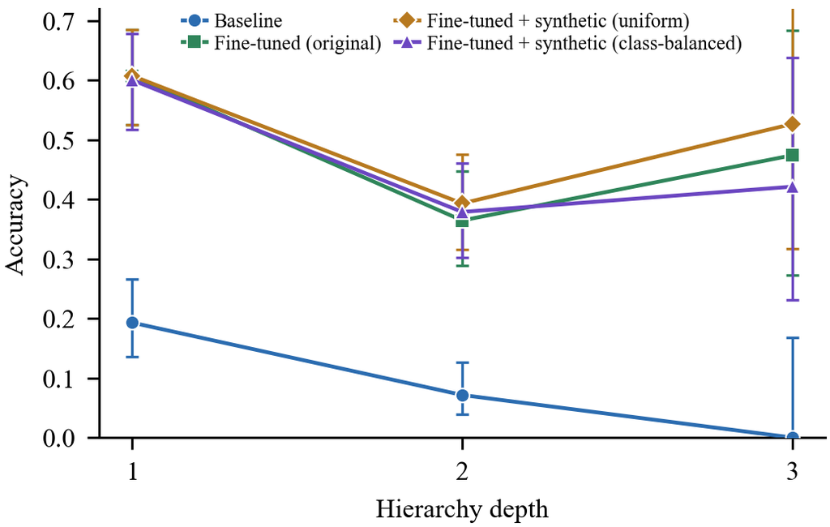

```
plots\fig_validation_metrics_all_models.png
```

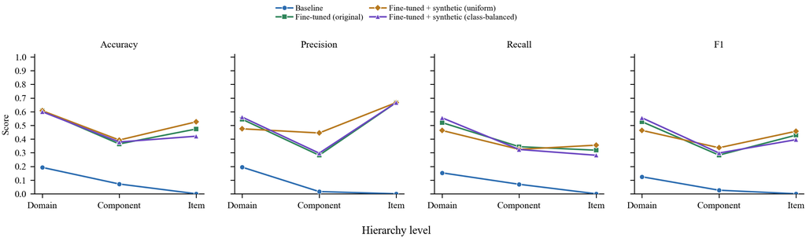

```
plots\fig_category_accuracy_compact_compare.png
```

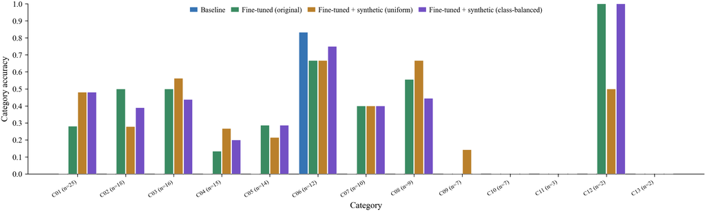

```
plots\fig_assumption_error_locality_models.png
```

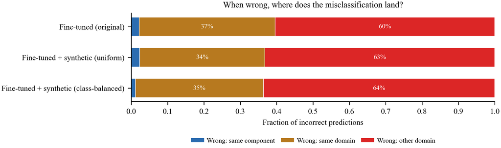

```
plots\fig_diagnostic_error_vs_support_models.png
```

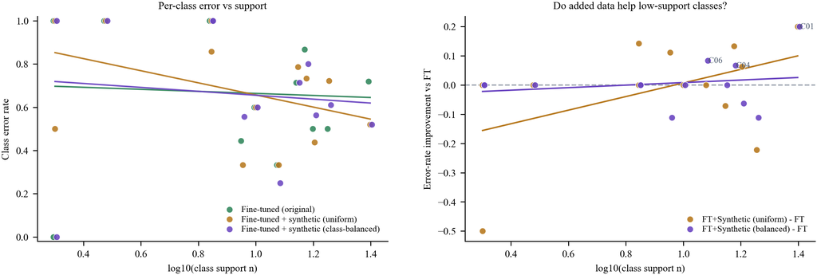

```
plots\fig_assumption_length_abstractness_heatmap4.png
```

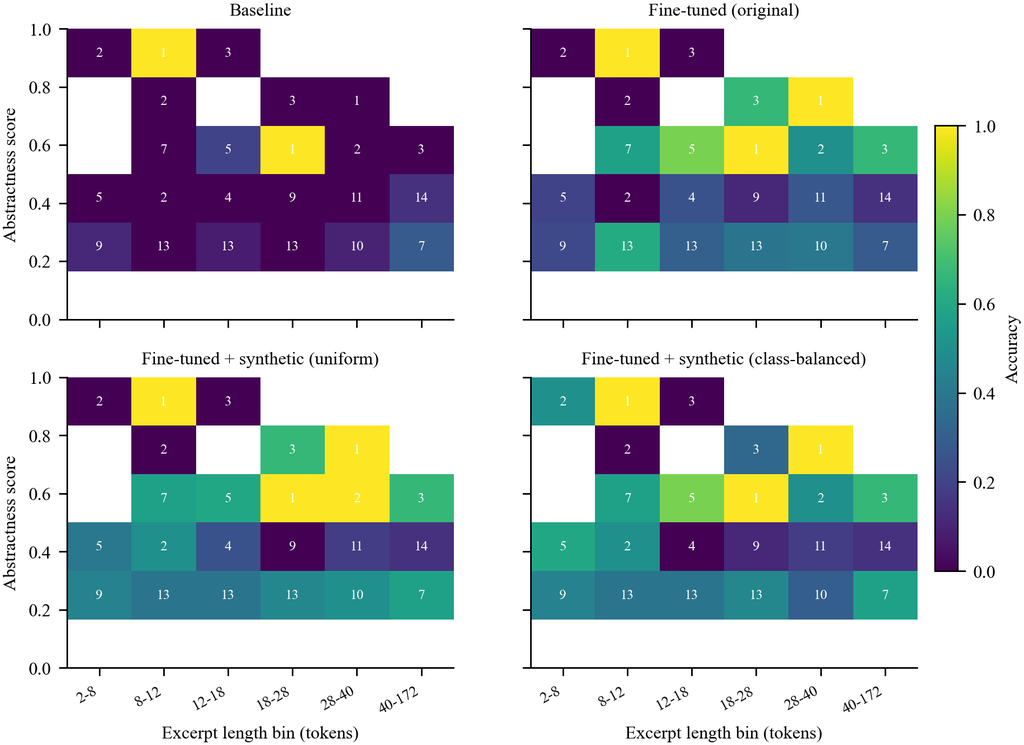

```python
# Show regenerated production figures
from IPython.display import Image, display

figs = [
    "fig_accuracy_hierarchy.png",
    "fig_validation_metrics_all_models.png",
    "fig_category_accuracy_compact_compare.png",
    "fig_assumption_error_locality_models.png",
    "fig_diagnostic_error_vs_support_models.png",
    "fig_assumption_length_abstractness_heatmap4.png",
]

for fp in figs:
    p = OUT_DIR / fp
    print(p)
    display(Image(filename=str(p)))
```

```python
# Moved to top of notebook.
# Keep this cell empty to avoid duplicate full-training blocks.
```